# Lab Analisis Exploratorio

Pedro Avila, Javier Benitez, Brandon Rivera

2026-02-07

```r
# dependecies
#install.packages("dplyr")
```

## Librerias

```r
library(ggplot2)
library(dplyr)
library(nortest)
library(scales)
library(lubridate)
```

## Inciso 1

- Haga una exploración rápida de sus datos, para eso haga un resumen de su conjunto de datos.

```r
movies <- read.csv("Movies_2026.csv")

str(movies)
```

```
## 'data.frame':    19883 obs. of  28 variables:
##  $ id                       : int  1627085 1626914 1626898 1626808 1626678 1626234 1626010 1625551 1625043 1624457 ...
##  $ budget                   : num  0 0 0 0 0 1 0 0 0 0 ...
##  $ genres                   : chr  "Drama|Crime" "Animation" "Animation" "Thriller|Mystery|Documentary" ...
##  $ homePage                 : chr  "" "" "" "" ...
##  $ productionCompany        : chr  "" "" "" "" ...
##  $ productionCompanyCountry : chr  "" "" "" "" ...
##  $ productionCountry        : chr  "" "" "" "" ...
##  $ revenue                  : num  0 0 0 0 0 1 0 0 0 0 ...
##  $ runtime                  : int  95 3 2 5 12 14 39 90 96 106 ...
##  $ video                    : logi  FALSE FALSE FALSE FALSE FALSE FALSE ...
##  $ director                 : chr  "Javad Hakami" "Kimmy Gatewood" "Kimmy Gatewood" "Felipe Roldán" ...
##  $ actors                   : chr  "Mohsen Ghasabian|Aida Mahiani|Mehran Ghafourian|Payam Ahmadinia|Masoud Karamati|Roya Javidnia|Nasim Adabi|Siavash Cheraghipour" "Kameron Jackson|Laura Weaving|sara weaving|Bertha Williams" "Cedric Mitchell|Cajun mills|Laura Williams" "Tomás Tuchsznajder|Matias …
##  $ actorsPopularity         : chr  "0.3453|0.1664|0.9684|0.3437|0.3713|0.2437|0.2796|0.2639" "0|0.0071|0|0" "0.0193|0|0.0143" "0|0|0|0|0|0|0" ...
##  $ actorsCharacter          : chr  "|||||||" "Prince Charming|Evil Stepmother|Fairy Godmother|Cinderella" "Aladdin|Jafar|Jasmine" "||||||" ...
##  $ originalTitle            : chr  "غوطه ور" "Cinderella" "Aladdin" "EL ANILLO Y EL DECK" ...
##  $ title                    : chr  "Immersed" "Cinderella" "Aladdin" "THE RING AND THE DECK" ...
##  $ originalLanguage         : chr  "fa" "en" "en" "es" ...
##  $ popularity               : num  0.0357 0.0357 0.0214 0.0429 0.0379 ...
##  $ releaseDate              : chr  "2026-02-01" "2026-02-01" "2026-02-01" "2026-02-01" ...
##  $ voteAvg                  : num  0 0 0 0 0 0 0 0 0 0 ...
##  $ voteCount                : int  0 0 0 0 0 0 0 0 0 0 ...
##  $ genresAmount             : int  2 1 1 3 1 1 1 1 3 1 ...
##  $ productionCoAmount       : int  0 0 0 0 0 0 0 0 0 0 ...
##  $ productionCountriesAmount: int  0 0 0 0 0 0 0 1 1 0 ...
##  $ actorsAmount             : int  8 4 3 7 3 3 5 4 5 5 ...
##  $ castWomenAmount          : int  2 0 0 0 0 0 0 3 1 2 ...
##  $ castMenAmount            : int  5 0 0 0 0 0 3 0 3 3 ...
##  $ releaseYear              : int  2026 2026 2026 2026 2026 2026 2026 2026 2026 2026 ...
```

- Al momento de usar `str()`, nos podemos hacer una idea de como son los datos en todo el dataset, este analisis se hace luego en el proyecto (en especifico en el inciso 2). Como nos podemos dar cuenta varios de estos campos llegan a tener informacion vacia para su tipo de dato respectivo.

```r
movies <- subset(movies, select = -id) # we ain't going to summarize the the id for pretty obvious reasons
summary(movies)
```

```
##      budget             genres            homePage         productionCompany
##  Min.   :        0   Length:19883       Length:19883       Length:19883
##  1st Qu.:        0   Class :character   Class :character   Class :character
##  Median :        0   Mode  :character   Mode  :character   Mode  :character
##  Mean   :  9413280
##  3rd Qu.:  1000000
##  Max.   :380000000
##
##  productionCompanyCountry productionCountry     revenue
##  Length:19883             Length:19883       Min.   :0.000e+00
##  Class :character         Class :character   1st Qu.:0.000e+00
##  Mode  :character         Mode  :character   Median :0.000e+00
##                                              Mean   :2.879e+07
##                                              3rd Qu.:3.306e+05
##                                              Max.   :2.847e+09
##
##     runtime         video           director            actors
##  Min.   :  0.00   Mode :logical   Length:19883       Length:19883
##  1st Qu.: 10.00   FALSE:19313     Class :character   Class :character
##  Median : 86.00   TRUE :84        Mode  :character   Mode  :character
##  Mean   : 66.09   NA's :486
##  3rd Qu.:103.00
##  Max.   :750.00
##
##  actorsPopularity   actorsCharacter    originalTitle         title
##  Length:19883       Length:19883       Length:19883       Length:19883
##  Class :character   Class :character   Class :character   Class :character
##  Mode  :character   Mode  :character   Mode  :character   Mode  :character
##
##
##
##
##  originalLanguage     popularity        releaseDate           voteAvg
##  Length:19883       Min.   :0.000e+00   Length:19883       Min.   : 0.000
##  Class :character   1st Qu.:5.460e-02   Class :character   1st Qu.: 0.000
##  Mode  :character   Median :8.502e+00   Mode  :character   Median : 5.400
##                     Mean   :2.625e+01                      Mean   : 3.837
##                     3rd Qu.:2.224e+01                      3rd Qu.: 6.800
##                     Max.   :1.147e+04                      Max.   :10.000
##
```

[output cut: 9 more lines]

```
##  Min.   :  0.00            Min.   :     0   Min.   :     0   Min.   :     0
##  1st Qu.:  1.00            1st Qu.:     3   1st Qu.:     0   1st Qu.:     0
##  Median :  1.00            Median :     9   Median :     2   Median :     3
##  Mean   :  1.23            Mean   :  1082   Mean   :  3517   Mean   :  8224
##  3rd Qu.:  1.00            3rd Qu.:    21   3rd Qu.:     6   3rd Qu.:    12
##  Max.   :155.00            Max.   :919590   Max.   :922162   Max.   :922017
##                                             NA's   :37       NA's   :162
##   releaseYear
##  Min.   :1902
##  1st Qu.:2013
##  Median :2021
##  Mean   :2017
##  3rd Qu.:2025
##  Max.   :2026
##  NA's   :2
```

- Al resumirlos no podemos agarrar informacion tan relevante para hacer cualquier tipo de analisis ademas de algunos valores numericos en dichos campos. Como ver cantidad de ingresos maximos y medios, prespuesto y ganancia por peliculas. No llega a ser informacion tan valiosa solo viendola de por si, ya que son datos generales entre todas y no de una solo empresa o por el estilo (se puede ‘queriear’ para lograrlo, pero ese no es el caso).

## Inciso 2

- Diga el tipo de cada una de las variables (cualitativa ordinal o nominal, cuantitativa continua, cuantitativa discreta)

**Cualitativas** Adicionalmente en estas clasificaciones las variables Actors y ActorsCharacters serian clasificados como cualitativos nominales pero no se agregaron porque es necesario una limpieza de datos antes.

```r
cual_nominales <- c(
  "genres",
  "homePage",
  "productionCompany",
  "productionCompanyCountry",
  "productionCountry",
  "video",
  "director",
  "originalTitle",
  "title",
  "originalLanguage"
)

cual_ordinales <- c(
  "releaseDate"
)

cualitativas <- c(cual_nominales, cual_ordinales)
cualitativas
```

```
##  [1] "genres"                   "homePage"
##  [3] "productionCompany"        "productionCompanyCountry"
##  [5] "productionCountry"        "video"
##  [7] "director"                 "originalTitle"
##  [9] "title"                    "originalLanguage"
## [11] "releaseDate"
```

```r
datos_cual <- movies[, cualitativas]
head(datos_cual, 5)
```

|  | genres | homePage | productionCompany | productionCompanyCountry | productionCountry | video | director | originalTitle | title | originalLanguage | releaseDate |
| --- | --- | --- | --- | --- | --- | --- | --- | --- | --- | --- | --- |
| 1 | Drama\|Crime |  |  |  |  | FALSE | Javad Hakami | غوطه ور | Immersed | fa | 2026-02-01 |
| 2 | Animation |  |  |  |  | FALSE | Kimmy Gatewood | Cinderella | Cinderella | en | 2026-02-01 |
| 3 | Animation |  |  |  |  | FALSE | Kimmy Gatewood | Aladdin | Aladdin | en | 2026-02-01 |
| 4 | Thriller\|Mystery\|Documentary |  |  |  |  | FALSE | Felipe Roldán | EL ANILLO Y EL DECK | THE RING AND THE DECK | es | 2026-02-01 |
| 5 | Animation |  |  |  |  | FALSE | Kimmy Gatewood | Crimson High 3 | Crimson High 3 | en | 2026-02-01 |

**Cuantitativas** Adicionalmente en estas clasificaciones la variable ActorsPopularity serian clasificados como cuantitativos continuos pero no se agregaron porque es necesario una limpieza de datos antes.

```r
cuant_discretas <- c(
  "budget",
  "revenue",
  "runtime",
  "voteAvg",
  "voteCount",
  "genresAmount",
  "productionCoAmount",
  "productionCountriesAmount",
  "actorsAmount",
  "castWomenAmount",
  "castMenAmount",
  "releaseYear"
)

cuant_continuas <- c(
  "popularity"
)

cuantitativas <- c(cuant_discretas, cuant_continuas)
cuantitativas
```

```
##  [1] "budget"                    "revenue"
##  [3] "runtime"                   "voteAvg"
##  [5] "voteCount"                 "genresAmount"
##  [7] "productionCoAmount"        "productionCountriesAmount"
##  [9] "actorsAmount"              "castWomenAmount"
## [11] "castMenAmount"             "releaseYear"
## [13] "popularity"
```

```r
datos_cuant <- movies[, cuantitativas]
head(datos_cuant, 5)
```

|  | budget | revenue | runtime | voteAvg | voteCount | genresAmount | productionCoAmount | productionCountriesAmount | actorsAmount | castWomenAmount | castMenAmount | releaseYear | popularity |
| --- | --- | --- | --- | --- | --- | --- | --- | --- | --- | --- | --- | --- | --- |
| 1 | 0 | 0 | 95 | 0 | 0 | 2 | 0 | 0 | 8 | 2 | 5 | 2026 | 0.0357 |
| 2 | 0 | 0 | 3 | 0 | 0 | 1 | 0 | 0 | 4 | 0 | 0 | 2026 | 0.0357 |
| 3 | 0 | 0 | 2 | 0 | 0 | 1 | 0 | 0 | 3 | 0 | 0 | 2026 | 0.0214 |
| 4 | 0 | 0 | 5 | 0 | 0 | 3 | 0 | 0 | 7 | 0 | 0 | 2026 | 0.0429 |
| 5 | 0 | 0 | 12 | 0 | 0 | 1 | 0 | 0 | 3 | 0 | 0 | 2026 | 0.0379 |

## Inciso 3

- Investigue si las variables cuantitativas siguen una distribución normal y haga una tabla de frecuencias de las variables cualitativas. Explique todos los resultados.

```r
lillie_results <- lapply(datos_cuant, lillie.test)
lillie_results
```

```
## $budget
##
##  Lilliefors (Kolmogorov-Smirnov) normality test
##
## data:  X[[i]]
## D = 0.37204, p-value < 2.2e-16
##
##
## $revenue
##
##  Lilliefors (Kolmogorov-Smirnov) normality test
##
## data:  X[[i]]
## D = 0.39765, p-value < 2.2e-16
##
##
## $runtime
##
##  Lilliefors (Kolmogorov-Smirnov) normality test
##
## data:  X[[i]]
## D = 0.1629, p-value < 2.2e-16
##
##
## $voteAvg
##
##  Lilliefors (Kolmogorov-Smirnov) normality test
##
## data:  X[[i]]
## D = 0.28937, p-value < 2.2e-16
##
##
## $voteCount
##
##  Lilliefors (Kolmogorov-Smirnov) normality test
##
## data:  X[[i]]
## D = 0.36364, p-value < 2.2e-16
##
##
```

[output cut: 47 more lines]

```
##
## $releaseYear
##
##  Lilliefors (Kolmogorov-Smirnov) normality test
##
## data:  X[[i]]
## D = 0.23746, p-value < 2.2e-16
##
##
## $popularity
##
##  Lilliefors (Kolmogorov-Smirnov) normality test
##
## data:  X[[i]]
## D = 0.43322, p-value < 2.2e-16
```

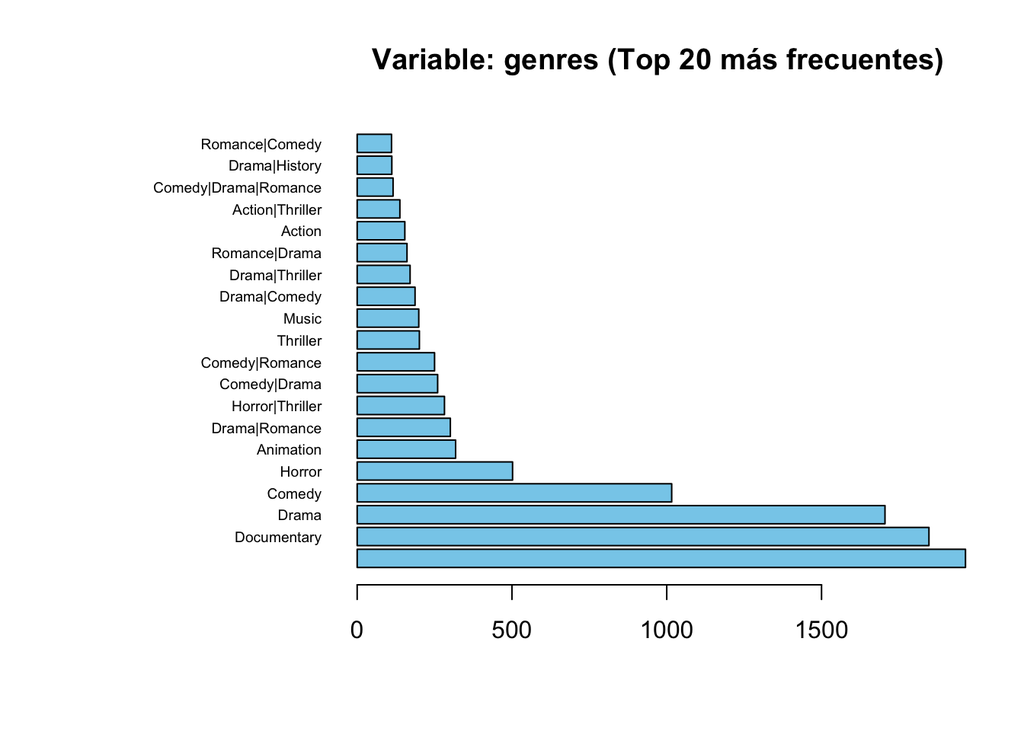

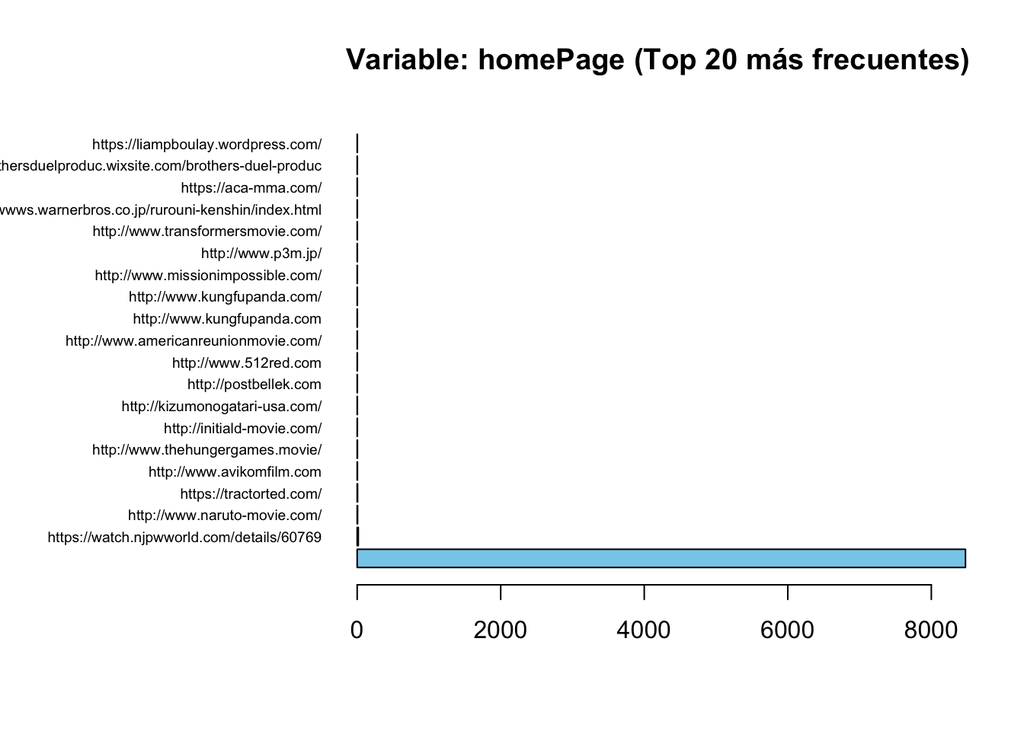

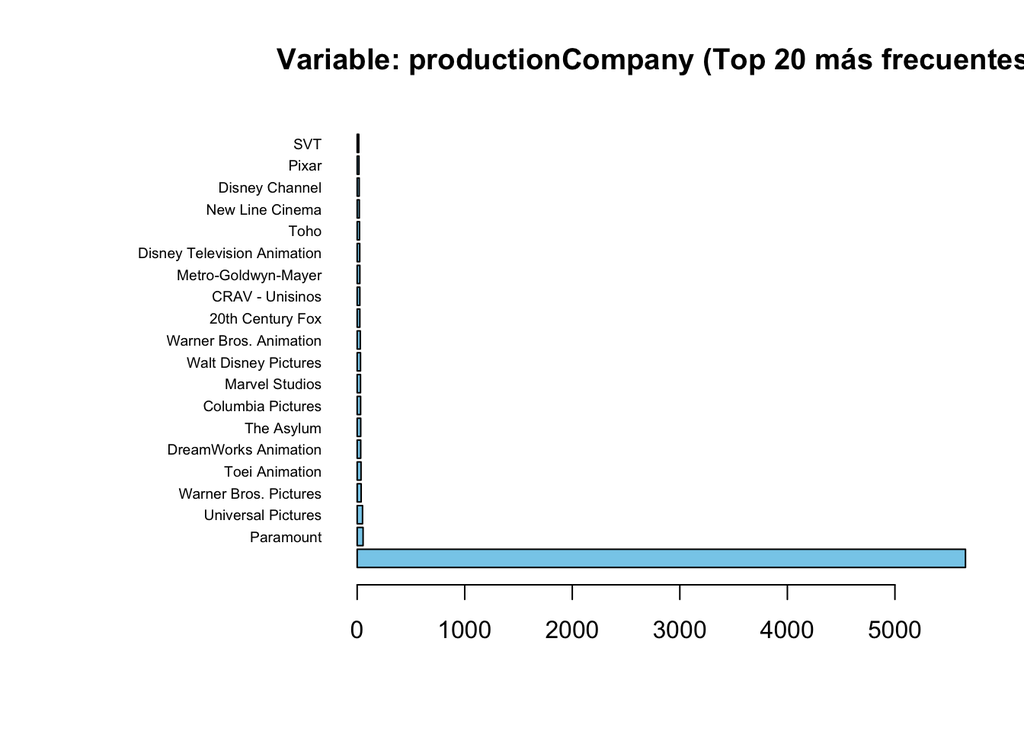

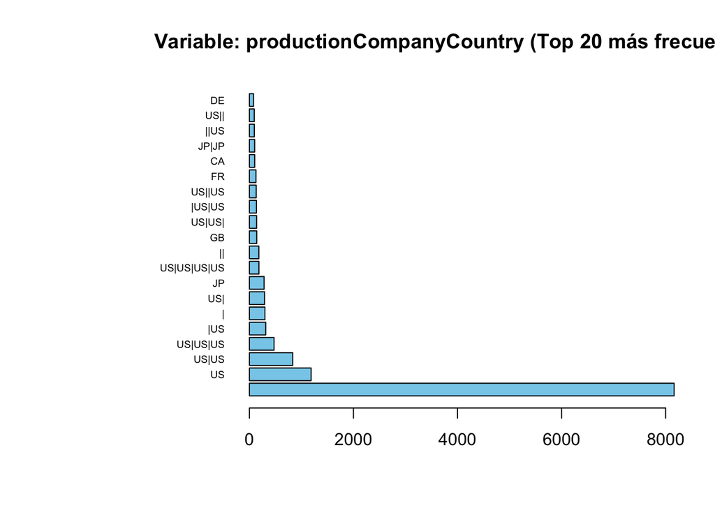

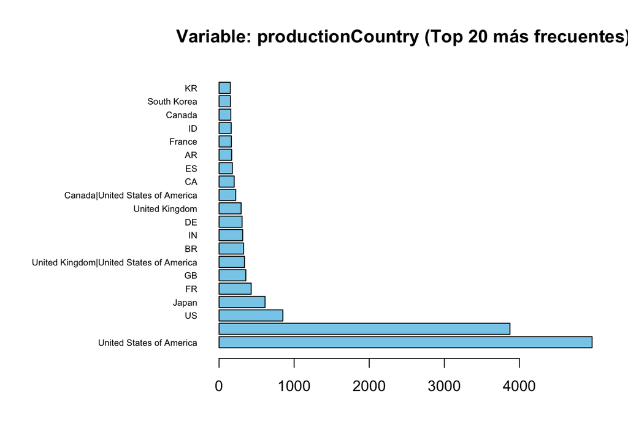

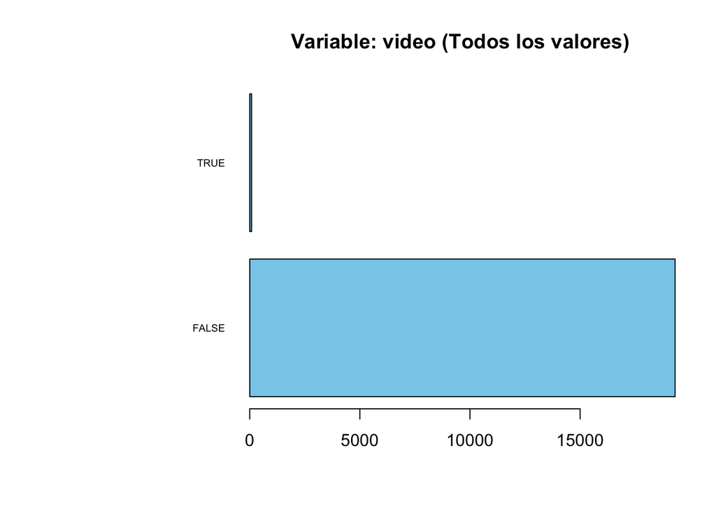

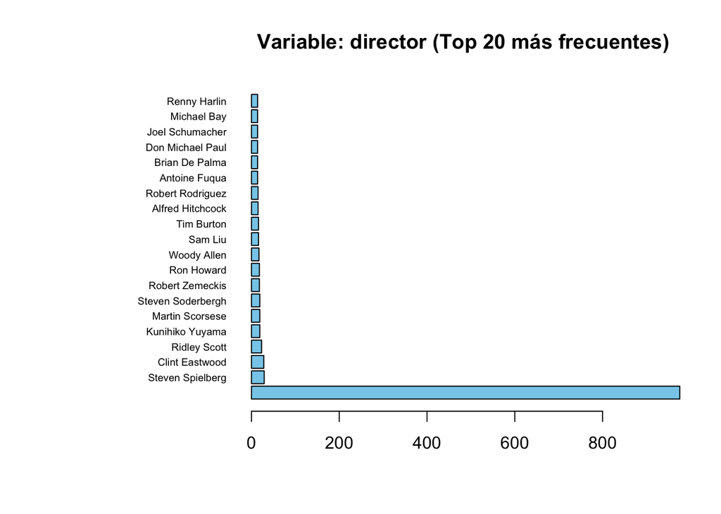

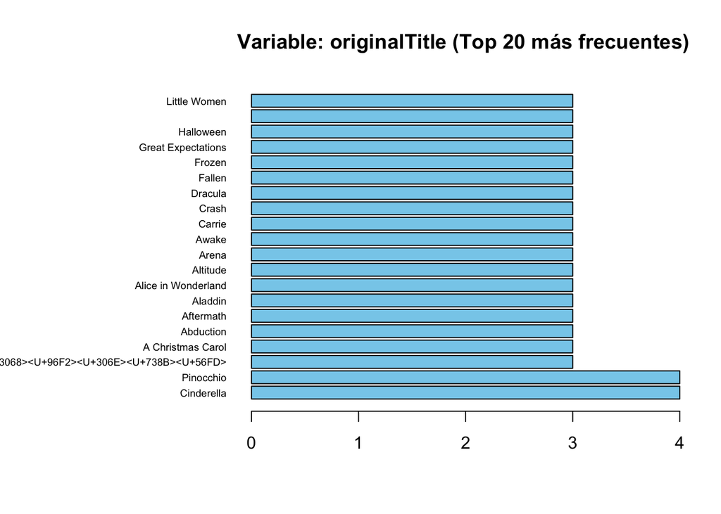

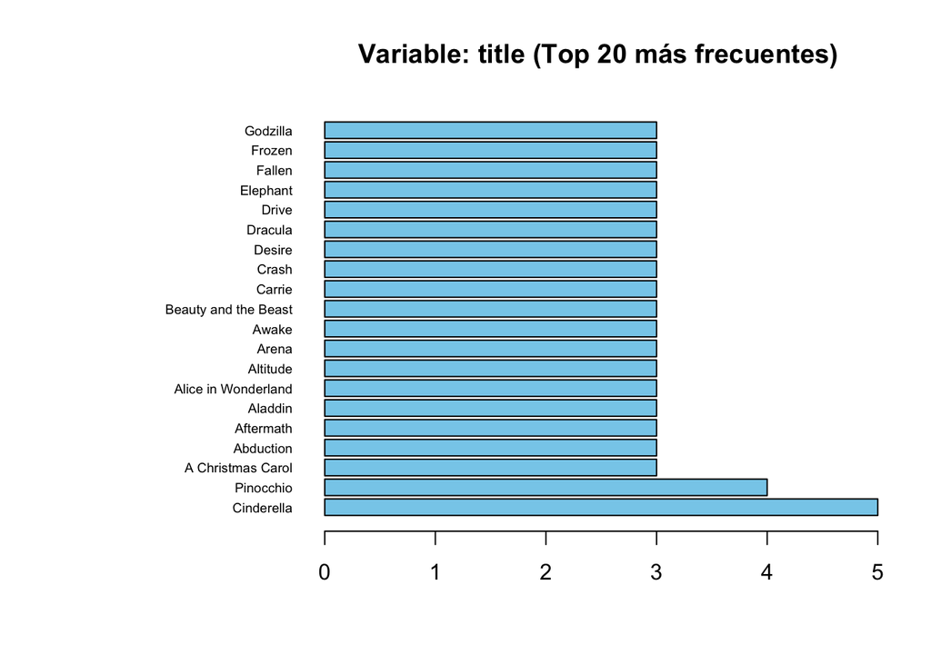

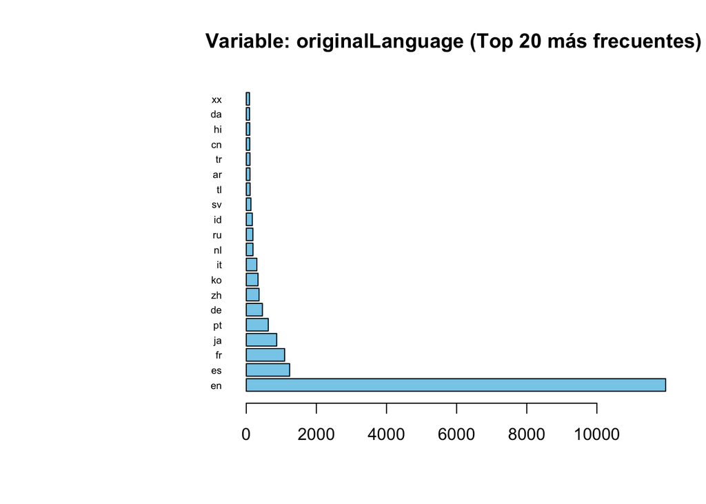

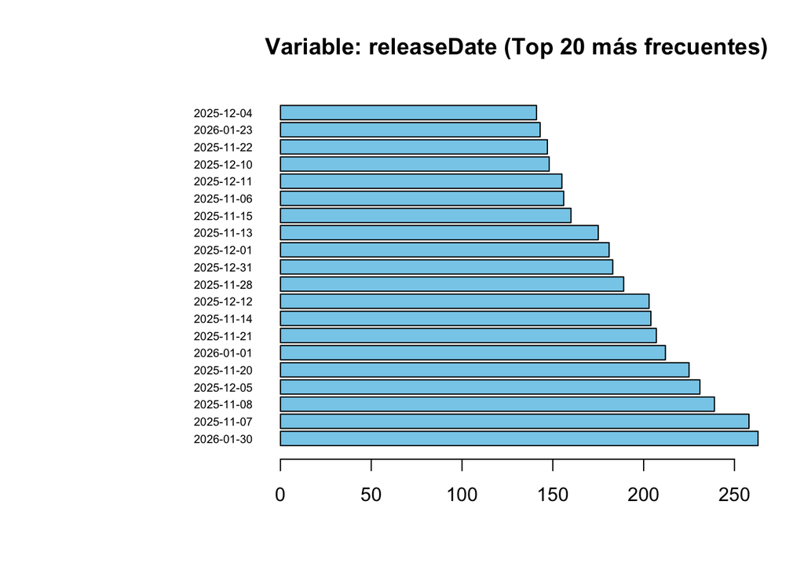

```r
frec <- table(unlist(datos_cual))

par(mar = c(5, 12, 4, 2))

# Ciclo para graficar cada variable cualitativa por separado
for (variable in cualitativas) {

  # 1. Crear tabla de frecuencia para la variable actual
  tabla <- table(movies[[variable]])

  # 2. Ordenar de mayor a menor
  tabla <- sort(tabla, decreasing = TRUE)

  # 3. Validar si son demasiados datos (ej. Titulos) para mostrar solo el Top 20
  if (length(tabla) > 20) {
    tabla_graficar <- tabla[1:20]
    subtitulo <- "(Top 20 más frecuentes)"
  } else {
    tabla_graficar <- tabla
    subtitulo <- "(Todos los valores)"
  }

  # 4. Generar el gráfico
  # Usamos 'horiz = TRUE' porque es más fácil leer nombres largos de lado
  barplot(tabla_graficar,
          main = paste("Variable:", variable, subtitulo),
          col = "skyblue",
          horiz = TRUE,      # Barras horizontales
          las = 1,           # Las etiquetas siempre horizontales
          cex.names = 0.6    # Tamaño de letra un poco más pequeño
  )
}
```

## Inciso 4

### 1. ¿Cuáles son las 10 películas que contaron con más presupuesto?

```r
movies = na.omit(movies )

df_1 <- movies[c('budget', 'title')]

head(df_1[order(df_1$budget, decreasing = TRUE),"title"], n  = 10)
```

```
##  [1] "Pirates of the Caribbean: On Stranger Tides"
##  [2] "Avengers: Age of Ultron"
##  [3] "Avengers: Endgame"
##  [4] "Avatar: Fire and Ash"
##  [5] "Pirates of the Caribbean: At World's End"
##  [6] "Avengers: Infinity War"
##  [7] "Superman Returns"
##  [8] "The Lion King"
##  [9] "Spider-Man 3"
## [10] "Harry Potter and the Half-Blood Prince"
```

### 2. ¿Cuáles son las 10 películas que más ingresos tuvieron?

```r
df_2 <- movies[c('revenue', 'title')]

head(df_2[order(movies$revenue, decreasing = TRUE),],n = 10)
```

|  | revenue | title |
| --- | --- | --- |
| 13101 | 2847246203 | Avatar |
| 15843 | 2797800564 | Avengers: Endgame |
| 15844 | 2046239637 | Avengers: Infinity War |
| 8482 | 1744338246 | Zootopia 2 |
| 17025 | 1667635327 | The Lion King |
| 18938 | 1631853496 | Spider-Man: No Way Home |
| 13288 | 1518815515 | The Avengers |
| 14978 | 1515047671 | Furious 7 |
| 16071 | 1450026933 | Frozen II |
| 14601 | 1405403694 | Avengers: Age of Ultron |

### 3. ¿Cuál es la película que más votos tuvo?

```r
df_2 <- movies[c('voteCount', 'title')]

head(df_2[order(movies$voteCount, decreasing = TRUE),], n = 1)
```

|  | voteCount | title |
| --- | --- | --- |
| 13402 | 30788 | Inception |

### 4. ¿Cuál es la peor película de acuerdo a los votos de todos los usuarios?

```r
df_2 <- movies[c('voteAvg', 'title')]

head(df_2[order(movies$voteAvg, decreasing = FALSE),], n = 1)
```

|  | voteAvg | title |
| --- | --- | --- |
| 1 | 0 | Immersed |

### 5. ¿Cuántas películas se hicieron en cada año? ¿En qué año se hicieron más películas? Haga un gráfico de barras

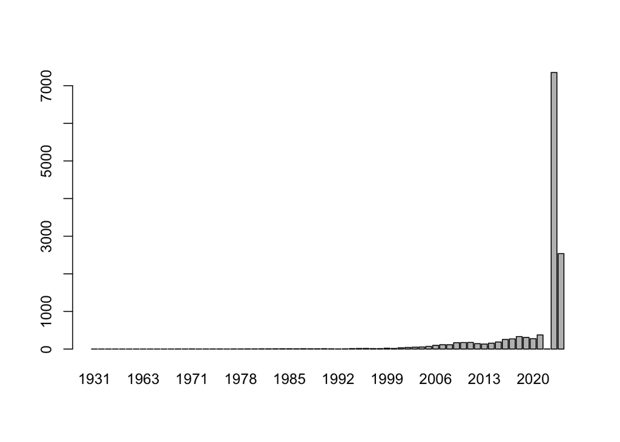

```r
library(dplyr)

year_count <- count(movies,movies$releaseYear)

barplot(year_count$n, names.arg = year_count$`movies$releaseYear`)
```

```r
head(year_count[order(year_count$n, decreasing = TRUE),],n = 1)
```

|  | movies$releaseYear | n |
| --- | --- | --- |
| 67 | 2025 | 7351 |

La grafica esta orenado desde los 30’s hasta los 20’s, siendo cada barra su a~no especifico, viendo la grafica podemos darnos cuenta como el a~no con mas cantidad de peliculas es el 2025.

### 6. ¿Cuál es el género principal de las 20 películas más recientes? ¿Cuál es el género principal que predomina en el conjunto de datos? Represéntelo usando un gráfico. ¿A qué género principal pertenecen las películas más largas?

```r
tabla_freq <- function(col) {
  as.data.frame(table(col), stringsAsFactors = FALSE) |>
    setNames(c("genero", "frecuencia"))
}
genres  <- c("genres")

movies$releaseDate <- as.Date(movies$releaseDate, format = "%Y-%m-%d")


peliculas_recientes <- movies[order(movies$releaseDate, decreasing = TRUE), ][1:20, ]
movies_separated_recientes <- peliculas_recientes |>
    tidyr::separate_rows(genres, sep = "\\|")
datos_generos_recientes <- movies_separated_recientes[, genres]
#head(datos_generos_recientes, 5)

lapply(datos_generos_recientes, tabla_freq)
```

```
## $genres
##         genero frecuencia
## 1                       4
## 2       Action          1
## 3    Animation          3
## 4       Comedy          3
## 5        Crime          3
## 6  Documentary          2
## 7        Drama          7
## 8      Mystery          2
## 9      Romance          1
## 10    Thriller          2
## 11    TV Movie          1
## 12         War          1
```

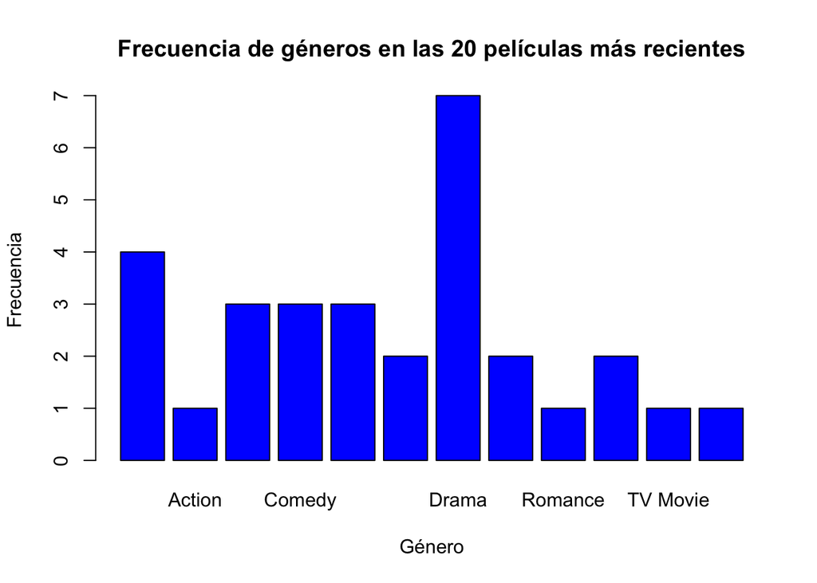

```r
barplot(
    table(datos_generos_recientes$genres),
    main = "Frecuencia de géneros en las 20 películas más recientes",
    xlab = "Género",
    ylab = "Frecuencia",
    col = "blue"
)
```

```r
peliculas_runtime <- movies[order(movies$runtime, decreasing = TRUE), ][1:20, ]
movies_separated_runtime <- peliculas_runtime |>
    tidyr::separate_rows(genres, sep = "\\|")
datos_generos_runtime <- movies_separated_runtime[, genres]
head(datos_generos_runtime, 5)
```

| genres |
| --- |
| Action |
| Drama |
| Romance |
| Documentary |

```r
lapply(datos_generos_runtime, tabla_freq)
```

```
## $genres
##             genero frecuencia
## 1                           6
## 2           Action          5
## 3        Adventure          1
## 4        Animation          1
## 5           Comedy          2
## 6      Documentary          4
## 7            Drama          4
## 8          Fantasy          1
## 9           Horror          2
## 10           Music          5
## 11         Romance          1
## 12 Science Fiction          1
```

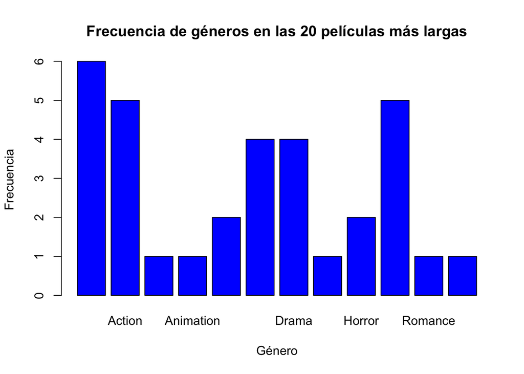

```r
barplot(
    table(datos_generos_runtime$genres),
    main = "Frecuencia de géneros en las 20 películas más largas",
    xlab = "Género",
    ylab = "Frecuencia",
    col = "blue"
)
```

```r
movies_genres <- peliculas_runtime |>
    tidyr::separate_rows(genres, sep = "\\|")
datos_generos <- movies_genres[, genres]
head(datos_generos, 5)
```

| genres |
| --- |
| Action |
| Drama |
| Romance |
| Documentary |

```r
lapply(datos_generos, tabla_freq)
```

```
## $genres
##             genero frecuencia
## 1                           6
## 2           Action          5
## 3        Adventure          1
## 4        Animation          1
## 5           Comedy          2
## 6      Documentary          4
## 7            Drama          4
## 8          Fantasy          1
## 9           Horror          2
## 10           Music          5
## 11         Romance          1
## 12 Science Fiction          1
```

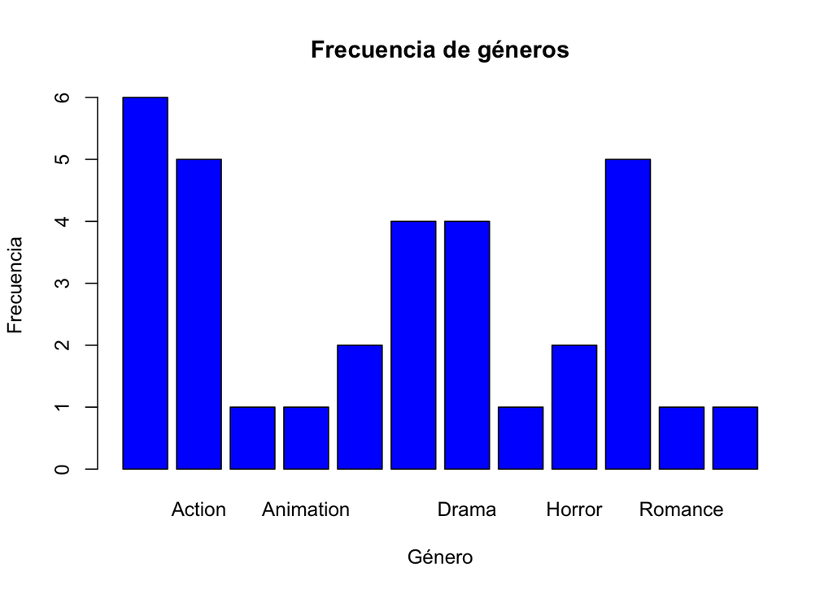

```r
barplot(
    table(datos_generos$genres),
    main = "Frecuencia de géneros",
    xlab = "Género",
    ylab = "Frecuencia",
    col = "blue"
)
```

### 7. ¿Las películas de qué genero principal obtuvieron mayores ganancias?

```r
peliculas_revenue <- movies[order(movies$revenue, decreasing = TRUE), ][1:20, ]
movies_separated_revenue <- peliculas_revenue |>
    tidyr::separate_rows(genres, sep = "\\|")
datos_generos_revenue <- movies_separated_revenue[, genres]
head(datos_generos_revenue, 5)
```

| genres |
| --- |
| Action |
| Adventure |
| Fantasy |
| Science Fiction |
| Adventure |

```r
lapply(datos_generos_revenue, tabla_freq)
```

```
## $genres
##             genero frecuencia
## 1           Action         13
## 2        Adventure         19
## 3        Animation          5
## 4           Comedy          3
## 5            Crime          2
## 6           Family          5
## 7          Fantasy          5
## 8          Mystery          1
## 9  Science Fiction         12
## 10        Thriller          2
```

### 8. ¿La cantidad de actores influye en los ingresos de las películas?¿se han hecho películas con más actores en los últimos años?

```r
number_of_actors <- movies |>
  tidyr::separate_rows(actors, sep = "\\|") |>
  group_by(title) |>
  summarise(actorsAmount = n(), .groups = "drop")
#number_of_actors

movies_with_actors <- movies |>
  left_join(number_of_actors, by = "title")

head(movies_with_actors,5)
```

|  | budget | genres | homePage | productionCompany | productionCompanyCountry | productionCountry | revenue | runtime | video | director | actors | actorsPopularity | actorsCharacter | originalTitle | title | originalLanguage | popularity | releaseDate | voteAvg | voteCount | genresAmount | productionCoAmount | productionCountriesAmount | actorsAmount.x | castWomenAmount | castMenAmount | releaseYear | actorsAmount.y |
| --- | --- | --- | --- | --- | --- | --- | --- | --- | --- | --- | --- | --- | --- | --- | --- | --- | --- | --- | --- | --- | --- | --- | --- | --- | --- | --- | --- | --- |
| 1 | 0 | Drama\|Crime |  |  |  |  | 0 | 95 | FALSE | Javad Hakami | Mohsen Ghasabian\|Aida Mahiani\|Mehran Ghafourian\|Payam Ahmadinia\|Masoud Karamati\|Roya Javidnia\|Nasim Adabi\|Siavash Cheraghipour | 0.3453\|0.1664\|0.9684\|0.3437\|0.3713\|0.2437\|0.2796\|0.2639 | \|\|\|\|\|\|\| | غوطه ور | Immersed | fa | 0.0357 | 2026-02-01 | 0 | 0 | 2 | 0 | 0 | 8 | 2 | 5 | 2026 | 8 |
| 2 | 0 | Animation |  |  |  |  | 0 | 3 | FALSE | Kimmy Gatewood | Kameron Jackson\|Laura Weaving\|sara weaving\|Bertha Williams | 0\|0.0071\|0\|0 | Prince Charming\|Evil Stepmother\|Fairy Godmother\|Cinderella | Cinderella | Cinderella | en | 0.0357 | 2026-02-01 | 0 | 0 | 1 | 0 | 0 | 4 | 0 | 0 | 2026 | 28 |
| 3 | 0 | Animation |  |  |  |  | 0 | 2 | FALSE | Kimmy Gatewood | Cedric Mitchell\|Cajun mills\|Laura Williams | 0.0193\|0\|0.0143 | Aladdin\|Jafar\|Jasmine | Aladdin | Aladdin | en | 0.0214 | 2026-02-01 | 0 | 0 | 1 | 0 | 0 | 3 | 0 | 0 | 2026 | 3 |
| 4 | 0 | Thriller\|Mystery\|Documentary |  |  |  |  | 0 | 5 | FALSE | Felipe Roldán | Tomás Tuchsznajder\|Matias Junas\|Martin Etcheverry\|Romeo Jeirfimczuk\|Agustin Pulido\|Alec Drach\|Franco Serio | 0\|0\|0\|0\|0\|0\|0 | \|\|\|\|\|\| | EL ANILLO Y EL DECK | THE RING AND THE DECK | es | 0.0429 | 2026-02-01 | 0 | 0 | 3 | 0 | 0 | 7 | 0 | 0 | 2026 | 7 |
| 5 | 0 | Animation |  |  |  |  | 0 | 12 | FALSE | Kimmy Gatewood | Cedric Mitchell\|Tara Carpenter\|Alissa Carter | 0.0193\|0.0071\|0 | Caleb\|Sarah\|Commander Vex | Crimson High 3 | Crimson High 3 | en | 0.0379 | 2026-02-01 | 0 | 0 | 1 | 0 | 0 | 3 | 0 | 0 | 2026 | 3 |

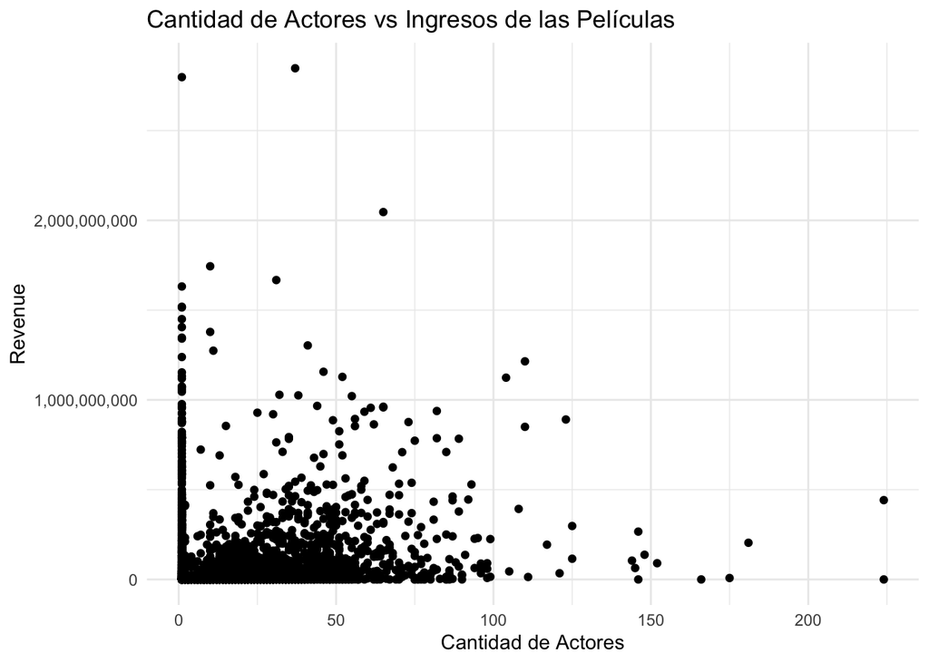

```r
# dispersión de cantidad de actores vs revenue
ggplot(movies_with_actors, aes(x = actorsAmount.y, y = revenue)) +
  geom_point(na.rm = TRUE) +
  labs(title = "Cantidad de Actores vs Ingresos de las Películas",
       x = "Cantidad de Actores",
       y = "Revenue") +
  scale_x_continuous(labels = comma) +
  scale_y_continuous(labels = comma) +
  theme_minimal()
```

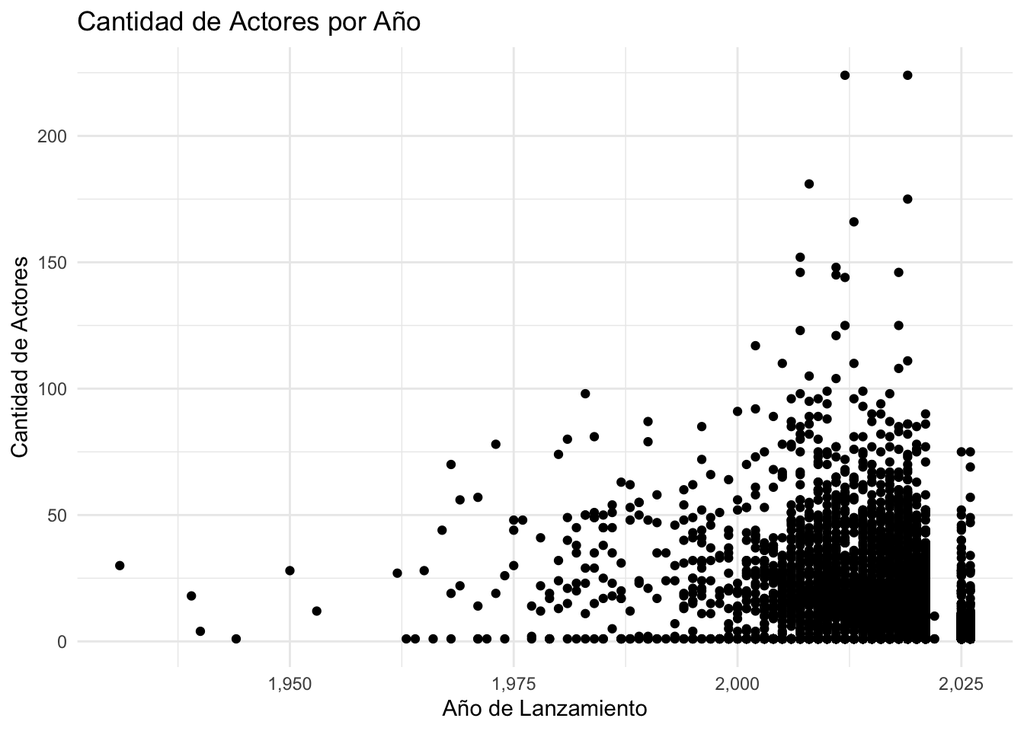

```r
# cantidad de actores por año
ggplot(movies_with_actors, aes(x = releaseYear, y = actorsAmount.y)) +
  geom_point(na.rm = TRUE) +
  labs(title = "Cantidad de Actores por Año",
       x = "Año de Lanzamiento",
       y = "Cantidad de Actores") +
  scale_x_continuous(labels = comma) +
  scale_y_continuous(labels = comma) +
  theme_minimal()
```

### 9. ¿Es posible que la cantidad de hombres y mujeres en el reparto influya en la popularidad y los ingresos de las películas?

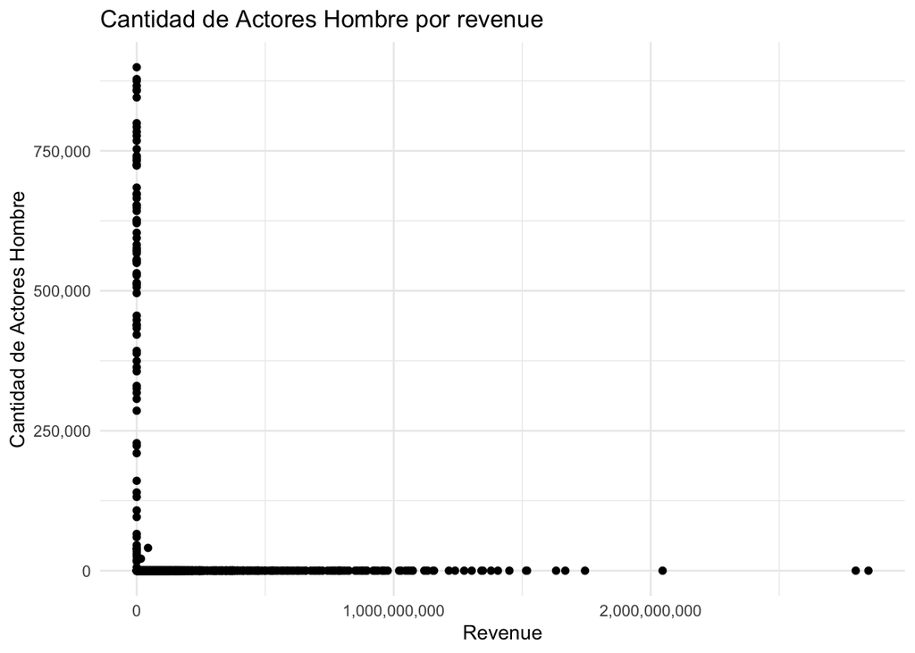

```r
ggplot(movies_with_actors, aes(x = revenue, y = castMenAmount)) +
  geom_point(na.rm = TRUE) +
  labs(title = "Cantidad de Actores Hombre por revenue",
       x = "Revenue",
       y = "Cantidad de Actores Hombre") +
  scale_x_continuous(labels = comma) +
  scale_y_continuous(labels = comma) +
  theme_minimal()
```

[figure not shown]

```r
ggplot(movies_with_actors, aes(x = castWomenAmount, y = revenue)) +
  geom_point(na.rm = TRUE) +
  labs(title = "Cantidad de Actores Mujer por revenue",
       x = "Revenue",
       y = "Cantidad de Actores Mujer") +
  scale_x_continuous(labels = comma) +
  scale_y_continuous(labels = comma) +
  theme_minimal()
```

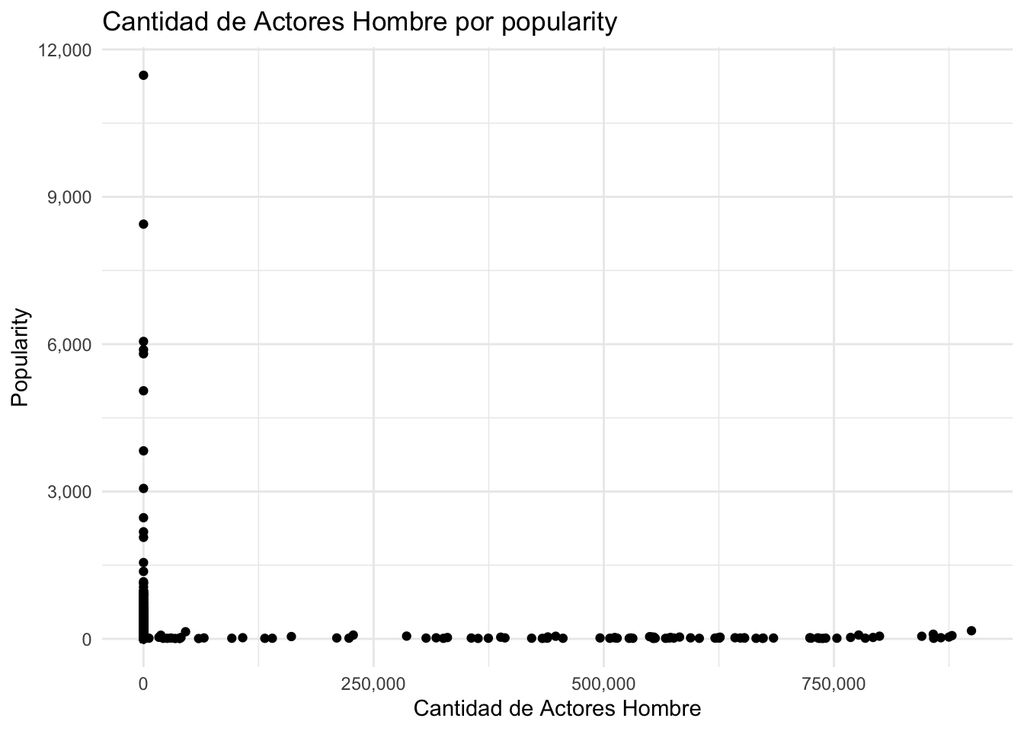

```r
  ggplot(movies_with_actors, aes(x = castMenAmount, y = popularity)) +
  geom_point(na.rm = TRUE) +
  labs(title = "Cantidad de Actores Hombre por popularity",
       x = "Cantidad de Actores Hombre",
       y = "Popularity") +
  scale_x_continuous(labels = comma) +
  scale_y_continuous(labels = comma) +
  theme_minimal()
```

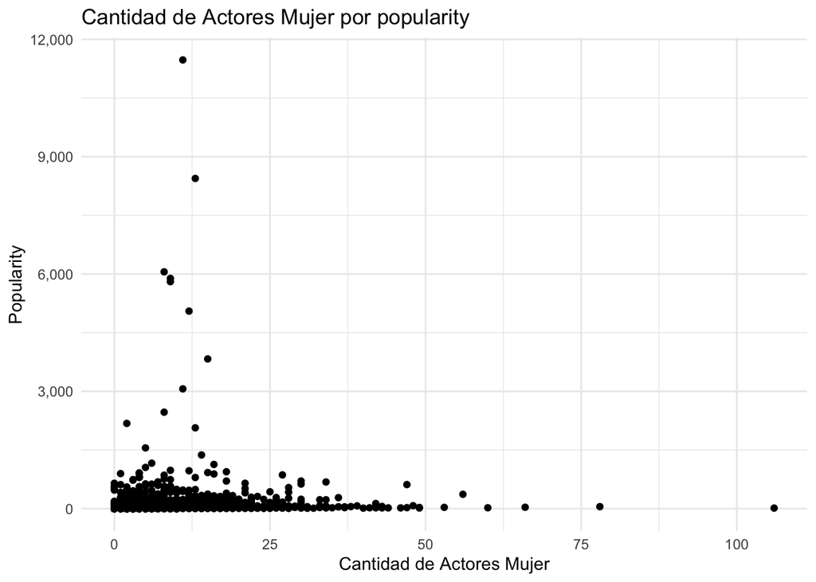

```r
ggplot(movies_with_actors, aes(x = castWomenAmount, y = popularity)) +
  geom_point(na.rm = TRUE) +
  labs(title = "Cantidad de Actores Mujer por popularity",
       x = "Cantidad de Actores Mujer",
       y = "Popularity") +
  scale_x_continuous(labels = comma) +
  scale_y_continuous(labels = comma) +
  theme_minimal()
```

De la misma forma que el inciso anterior ninguna de las graficas sigue una forma de relacion lineal entonces se podria asumir que no hay relacion, por otro lado esto tambien puede ser por data incompleta o mal formateada.

### 10. ¿Quiénes son los directores que hicieron las 20 películas mejor calificadas?

```r
top_rated_movies <- movies |>
  arrange(desc(voteAvg)) |>
  head(20) |>
  select(director, title, voteAvg)

top_rated_movies
```

|  | director | title | voteAvg |
| --- | --- | --- | --- |
| 1 | Jason Waters | Crocodile Dose | 10 |
| 2 | Fischer Sawatzky | The Exchange | 10 |
| 3 | Kanan Gill | What is This ? | 10 |
| 4 | Vitorio Stankov | Silver Gold Wood | 10 |
| 5 | Daniela Vidovich | Adiós Para Nunca | 10 |
| 6 | Tirion Liddell | GO TO SLEEP | 10 |
| 7 | Guillaume Huss Seewald | Le Moment sera le Bon | 10 |
| 8 | Cyprien Klein | Satiata | 10 |
| 9 | Joe Arodann\|Anaïs Richerand | Orphen | 10 |
| 10 | Séo Patois\|Lorraine Jacques | Regarde toi | 10 |

[output cut: 10 more lines]

### 11.¿Cómo se correlacionan los presupuestos con los ingresos? ¿Los altos presupuestos significan altos ingresos?

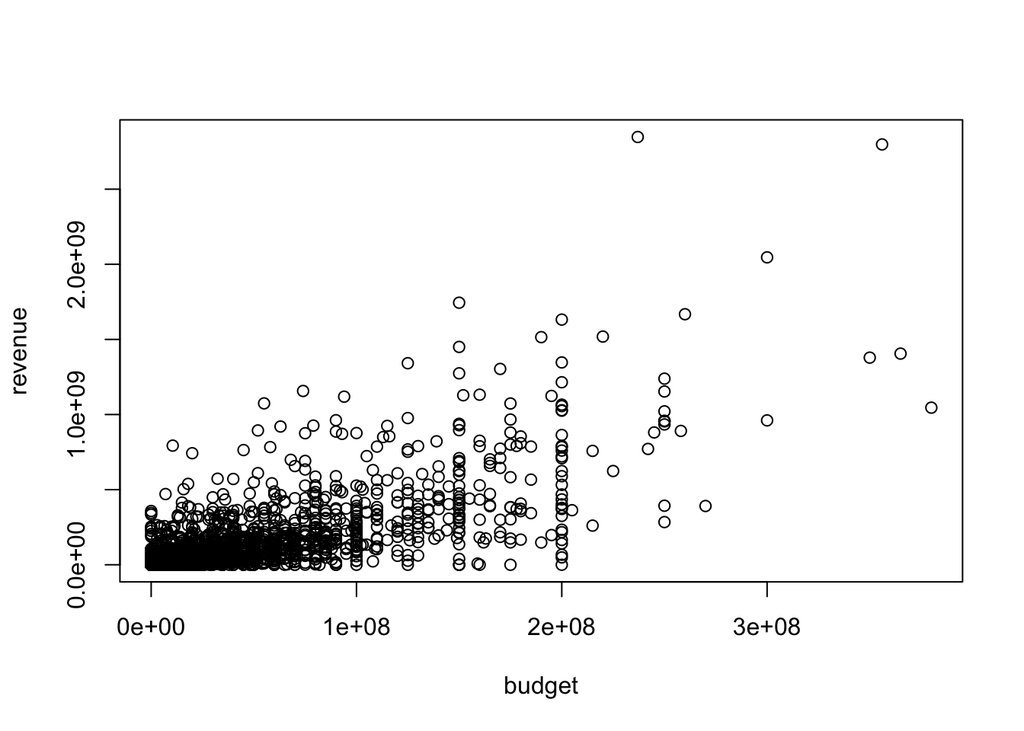

```r
with(movies, plot(budget,revenue))
```

### 12. ¿Se asocian ciertos meses de lanzamiento con mejores ingresos?

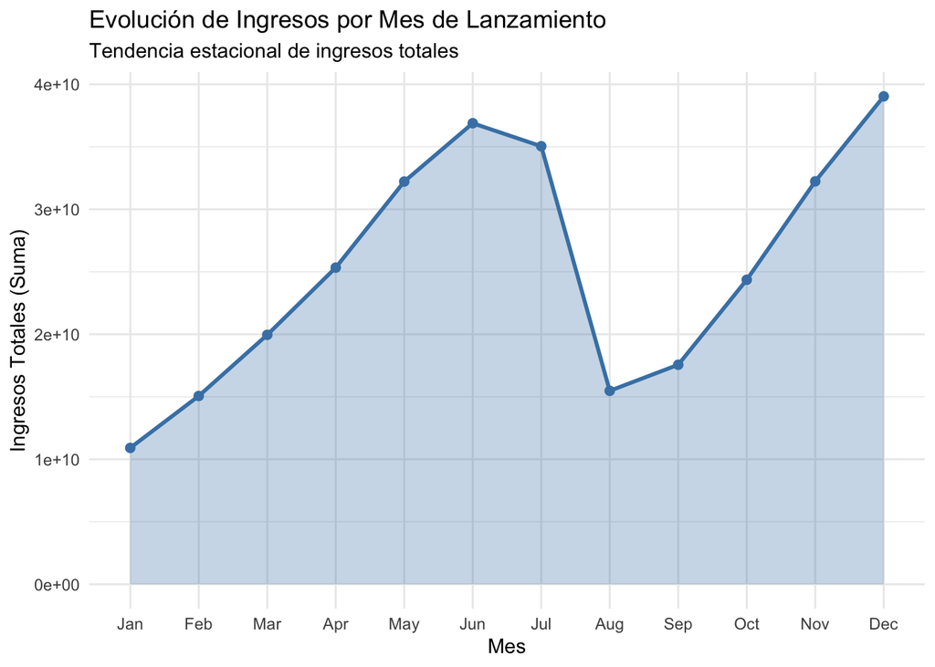

```r
movies$releaseDate <- as.Date(movies$releaseDate)
movies$mes <- month(movies$releaseDate, label = TRUE, abbr = TRUE)

df_mensual <- movies %>%
  group_by(mes) %>%
  summarize(total_revenue = sum(revenue, na.rm = TRUE))

ggplot(df_mensual, aes(x = mes, y = total_revenue, group = 1)) +
  geom_area(fill = "steelblue", alpha = 0.3) +
  geom_line(color = "steelblue", linewidth = 1) +
  geom_point(color = "steelblue", size = 2) +
  labs(
    title = "Evolución de Ingresos por Mes de Lanzamiento",
    subtitle = "Tendencia estacional de ingresos totales",
    x = "Mes",
    y = "Ingresos Totales (Suma)"
  ) +
  theme_minimal()
```

### 13. ¿En qué meses se han visto los lanzamientos con mejores ingresos?¿cuantas películas, en promedio, se han lanzado por mes?

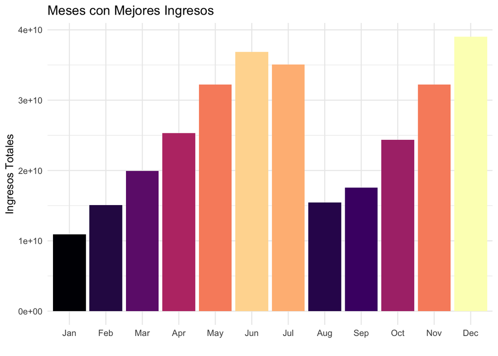

```r
movies_clean <- movies %>%
  mutate(
    date = as.Date(releaseDate),
    mes = month(date, label = TRUE, abbr = TRUE),
    anio = year(date)
  ) %>%
  filter(!is.na(mes))

conteo_mensual <- movies_clean %>%
  group_by(anio, mes) %>%
  summarise(n_pelis = n(), revenue_total = sum(revenue, na.rm = TRUE), .groups = "drop")

metricas_finales <- conteo_mensual %>%
  group_by(mes) %>%
  summarise(
    promedio_lanzamientos = mean(n_pelis),
    ingresos_totales = sum(revenue_total)
  )

g1 <- ggplot(metricas_finales, aes(x = mes, y = ingresos_totales, fill = ingresos_totales)) +
  geom_col() +
  scale_fill_viridis_c(option = "magma", guide = "none") +
  labs(title = "Meses con Mejores Ingresos", y = "Ingresos Totales", x = "") +
  theme_minimal()

g2 <- ggplot(metricas_finales, aes(x = mes, y = promedio_lanzamientos)) +
  geom_col(fill = "steelblue") +
  geom_text(aes(label = round(promedio_lanzamientos, 1)),
            vjust = -0.5, size = 3.5) +
  labs(
    title = "Promedio de Películas Lanzadas por Mes",
    subtitle = "¿Cuántas películas se estrenan realmente en un mes típico?",
    x = "Mes",
    y = "Cant. Promedio de Estrenos"
  ) +
  theme_minimal()

print(g1)
```

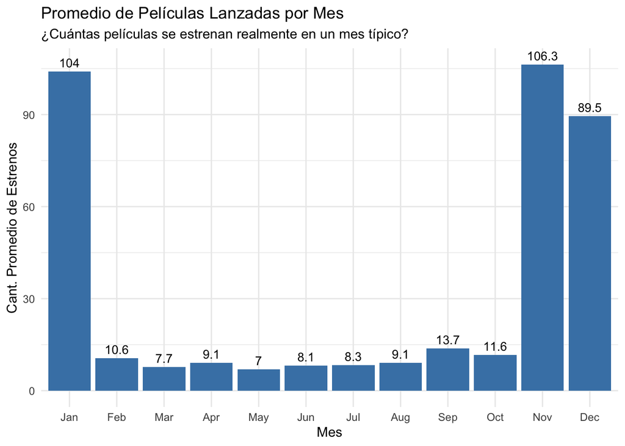

```r
print(g2)
```

### 14. ¿Cómo se correlacionan las calificaciones con el éxito comercial?

Las peliculas entre los 7.5 de calificacion son las peliculas que mas ingresos tienen pero hay muchas peliculas que son un 10 total pero que no generaron apenas ingresos y de igual manera peliculas con una puntuacion de 7.5 podrian no haber generado ningun ingreso no es garantizado un gran ingreso pero si es mas probable

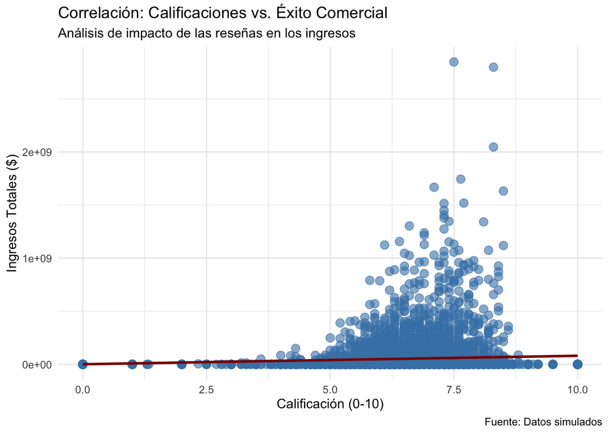

```r
ggplot(movies, aes(x = voteAvg, y = revenue)) +
  geom_point(color = "steelblue", alpha = 0.6, size = 3) +

  geom_smooth(method = "lm", color = "darkred", se = TRUE) +

  labs(
    title = "Correlación: Calificaciones vs. Éxito Comercial",
    subtitle = "Análisis de impacto de las reseñas en los ingresos",
    x = "Calificación (0-10)",
    y = "Ingresos Totales ($)",
    caption = "Fuente: Datos simulados"
  ) +
  theme_minimal()
```

### 15. ¿Qué estrategias de marketing, como videos promocionales o páginas oficiales, generan mejores resultados?

Las peliculas con pagina oficial tienen mas revenue por ende el sitio web es mejor estrategia

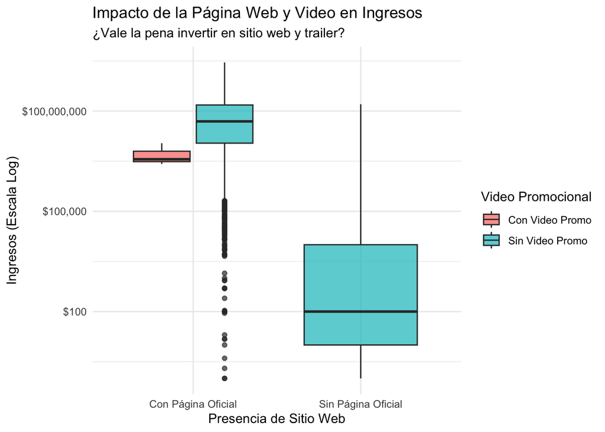

```r
peliculas_clean <- movies %>%
  mutate(
    tiene_web = ifelse(!is.na(homePage) & homePage != "", "Con Página Oficial", "Sin Página Oficial"),

    tiene_video = ifelse(video == TRUE, "Con Video Promo", "Sin Video Promo")
  )

ggplot(peliculas_clean, aes(x = tiene_web, y = revenue, fill = tiene_video)) +

  geom_boxplot(alpha = 0.7) +

  scale_y_log10(labels = scales::dollar_format()) +

  labs(
    title = "Impacto de la Página Web y Video en Ingresos",
    subtitle = "¿Vale la pena invertir en sitio web y trailer?",
    x = "Presencia de Sitio Web",
    y = "Ingresos (Escala Log)",
    fill = "Video Promocional"
  ) +
  theme_minimal()
```

### 16. ¿La popularidad del elenco está directamente correlacionada con el éxito de taquilla?

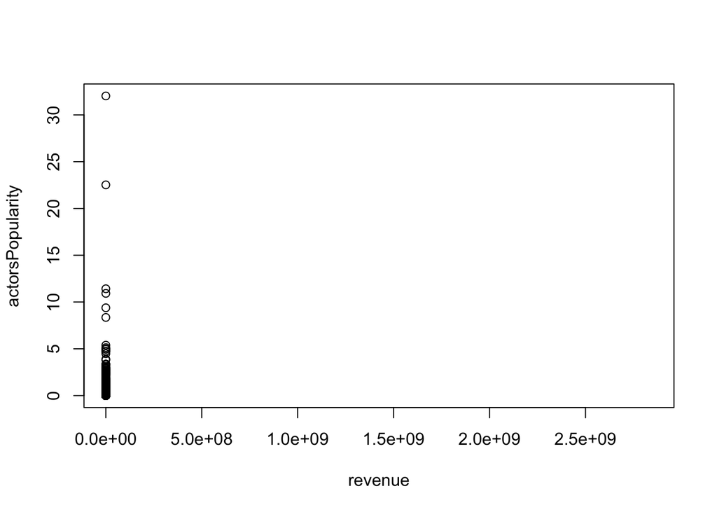

```r
  with(movies, plot(revenue,actorsPopularity))
```

No como se puede ver en esta grafica no esta directamente relacionada la popularidad de un actor con el ingreso de la pelicula